# Literacy 230925

coop711

2023-09-25

## 응답 집계

Counts

| Q1 | Q2 | Q3 | Q4 | Q5 | Q6 | Q7 | Q8 | Q9 | Q10 | Q11 | Q12 | Q13 | Q14 | Q15 | Q16 | Q17 | Q18 | Q19 | Q20 | Q21 | Q22 | Q23 | Q24 | Q25 |
| --- | --- | --- | --- | --- | --- | --- | --- | --- | --- | --- | --- | --- | --- | --- | --- | --- | --- | --- | --- | --- | --- | --- | --- | --- |
| 16 | 16 | 651 | 16 | 20 | 69 | 772 | 69 | 112 | 30 | 738 | 31 | 19 | 43 | 41 | 679 | 212 | 47 | 754 | 52 | 48 | 48 | 751 | 75 | 43 |
| 20 | 27 | 71 | 19 | 754 | 70 | 27 | 70 | 465 | 718 | 48 | 273 | 712 | 61 | 120 | 85 | 63 | 727 | 27 | 85 | 666 | 148 | 45 | 65 | 656 |
| 818 | 75 | 53 | 801 | 68 | 163 | 37 | 92 | 257 | 75 | 47 | 520 | 67 | 33 | 590 | 52 | 53 | 44 | 48 | 683 | 67 | 75 | 38 | 666 | 117 |
| 2 | 738 | 81 | 20 | 14 | 554 | 20 | 625 | 22 | 33 | 23 | 32 | 58 | 719 | 105 | 40 | 528 | 38 | 27 | 36 | 75 | 585 | 22 | 50 | 40 |

%

| Q1 | Q2 | Q3 | Q4 | Q5 | Q6 | Q7 | Q8 | Q9 | Q10 | Q11 | Q12 | Q13 | Q14 | Q15 | Q16 | Q17 | Q18 | Q19 | Q20 | Q21 | Q22 | Q23 | Q24 | Q25 |
| --- | --- | --- | --- | --- | --- | --- | --- | --- | --- | --- | --- | --- | --- | --- | --- | --- | --- | --- | --- | --- | --- | --- | --- | --- |
| 2 | 2 | 76 | 2 | 2 | 8 | 90 | 8 | 13 | 4 | 86 | 4 | 2 | 5 | 5 | 79 | 25 | 5 | 88 | 6 | 6 | 6 | 88 | 9 | 5 |
| 2 | 3 | 8 | 2 | 88 | 8 | 3 | 8 | 54 | 84 | 6 | 32 | 83 | 7 | 14 | 10 | 7 | 85 | 3 | 10 | 78 | 17 | 5 | 8 | 77 |
| 96 | 9 | 6 | 94 | 8 | 19 | 4 | 11 | 30 | 9 | 5 | 61 | 8 | 4 | 69 | 6 | 6 | 5 | 6 | 80 | 8 | 9 | 4 | 78 | 14 |
| 0 | 86 | 9 | 2 | 2 | 65 | 2 | 73 | 3 | 4 | 3 | 4 | 7 | 84 | 12 | 5 | 62 | 4 | 3 | 4 | 9 | 68 | 3 | 6 | 5 |

## 막대그래프

막대그래프로 답안 분포를 시각적으로 살핀다. 차후 나오는 정답률과 함께 어느 문항에서 어느 답안을 많이 고르는지 파악하는 데 활용한다.

### `barplot`

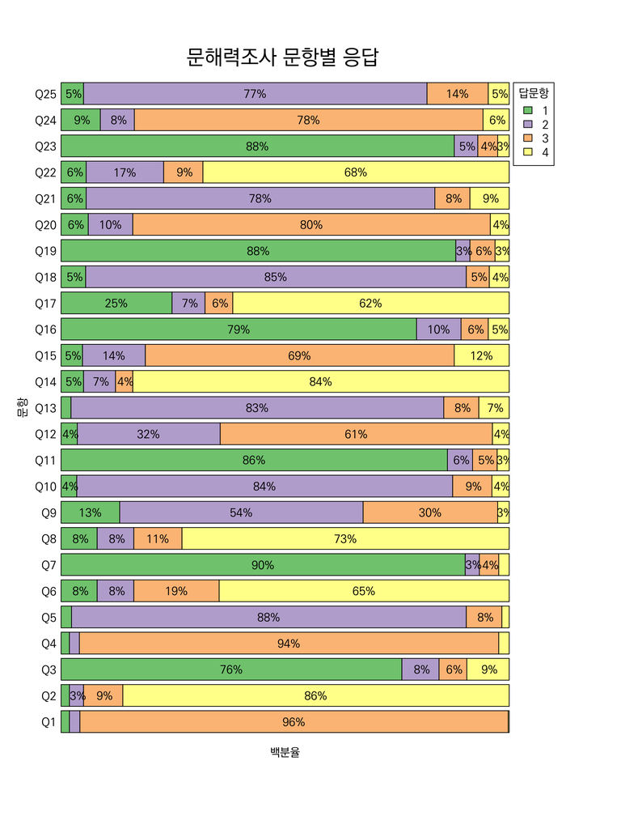

### `ggplot`

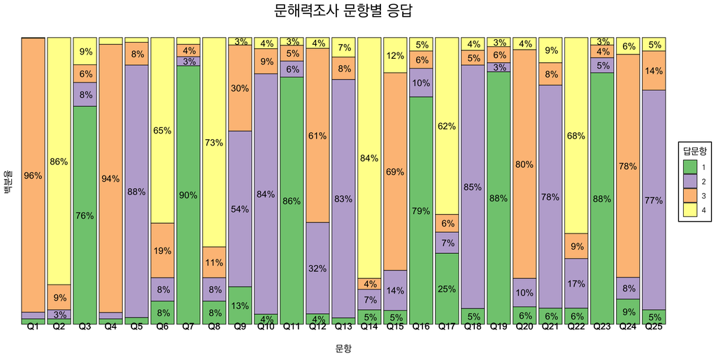

## 문해력 점수 계산

### 정답과 대조하여 R(Right)/W(Wrong) 표시

| Q1 | Q2 | Q3 | Q4 | Q5 | Q6 | Q7 | Q8 | Q9 | Q10 | Q11 | Q12 | Q13 | Q14 | Q15 | Q16 | Q17 | Q18 | Q19 | Q20 | Q21 | Q22 | Q23 | Q24 | Q25 |
| --- | --- | --- | --- | --- | --- | --- | --- | --- | --- | --- | --- | --- | --- | --- | --- | --- | --- | --- | --- | --- | --- | --- | --- | --- |
| R | R | R | R | W | R | R | W | W | R | R | W | R | R | W | R | R | R | R | R | R | W | R | R | R |
| R | R | R | R | R | R | R | R | R | R | R | R | R | R | R | R | R | R | R | R | R | R | R | R | R |
| R | R | R | R | R | R | R | R | W | R | R | W | R | R | R | R | W | R | R | R | R | W | R | R | R |
| R | R | W | R | R | W | R | R | R | R | R | R | R | R | R | R | R | R | R | R | R | R | R | R | R |
| R | R | R | R | R | R | R | R | R | R | R | R | R | R | W | R | R | R | R | R | R | R | R | R | R |
| R | R | R | R | R | R | R | R | W | R | R | R | R | R | R | R | R | R | R | R | R | R | R | R | R |

### 학생별 점수 산출

*76*, *100*, *84*, *92*, *96*, *96*, *60*, *40*, *92*, *80*, *84*, *84*, *88*, *92*, *84*, *60*, *92*, *64*, *88*, *92*, *92*, *52*, *100*, *84*, *92*, *20*, *72*, *88*, *92*, *76*, *96*, *80*, *96*, *24*, *92*, *84*, *88*, *60*, *88*, *88*, *56*, *92*, *92*, *32*, *68*, *36*, *88*, *88*, *68*, *80*, *92*, *96*, *88*, *92*, *80*, *80*, *92*, *84*, *92*, *60*, *72*, *92*, *96*, *84*, *92*, *96*, *96*, *96*, *92*, *68*, *80*, *88*, *92*, *76*, *88*, *100*, *96*, *84*, *84*, *80*, *88*, *88*, *88*, *96*, *56*, *92*, *72*, *84*, *72*, *88*, *92*, *88*, *88*, *92*, *88*, *92*, *92*, *88*, *68*, *80*, *80*, *76*, *84*, *80*, *96*, *80*, *80*, *84*, *76*, *84*, *88*, *84*, *36*, *84*, *100*, *80*, *84*, *80*, *60*, *88*, *84*, *68*, *92*, *44*, *68*, *68*, *92*, *80*, *80*, *84*, *8*, *100*, *68*, *92*, *84*, *84*, *92*, *80*, *88*, *88*, *84*, *80*, *92*, *92*, *48*, *88*, *84*, *28*, *84*, *76*, *100*, *8*, *100*, *92*, *92*, *84*, *88*, *12*, *16*, *84*, *96*, *56*, *96*, *96*, *84*, *100*, *100*, *100*, *72*, *72*, *96*, *96*, *80*, *100*, *72*, *24*, *44*, *76*, *68*, *96*, *96*, *36*, *80*, *96*, *56*, *92*, *76*, *92*, *92*, *40*, *84*, *100*, *92*, *56*, *88*, *88*, *92*, *40*, *52*, *92*, *100*, *60*, *52*, *76*, *32*, *92*, *96*, *84*, *88*, *80*, *40*, *84*, *92*, *44*, *96*, *92*, *76*, *92*, *60*, *92*, *92*, *96*, *40*, *92*, *88*, *76*, *88*, *24*, *92*, *96*, *88*, *92*, *60*, *92*, *80*, *80*, *88*, *92*, *92*, *100*, *80*, *12*, *84*, *92*, *96*, *76*, *76*, *100*, *84*, *96*, *76*, *76*, *84*, *100*, *96*, *100*, *76*, *36*, *36*, *64*, *32*, *100*, *100*, *92*, *80*, *84*, *88*, *88*, *28*, *100*, *76*, *60*, *92*, *64*, *80*, *84*, *92*, *76*, *72*, *92*, *92*, *96*, *80*, *96*, *84*, *76*, *92*, *88*, *88*, *96*, *92*, *88*, *88*, *84*, *20*, *64*, *76*, *72*, *92*, *92*, *20*, *48*, *72*, *72*, *56*, *88*, *80*, *52*, *64*, *68*, *24*, *92*, *92*, *12*, *80*, *80*, *88*, *100*, *92*, *64*, *92*, *88*, *84*, *80*, *88*, *88*, *68*, *92*, *24*, *96*, *88*, *88*, *48*, *96*, *96*, *84*, *84*, *88*, *88*, *96*, *76*, *44*, *60*, *96*, *52*, *84*, *92*, *96*, *100*, *80*, *84*, *96*, *92*, *96*, *96*, *88*, *88*, *100*, *80*, *88*, *48*, *88*, *84*, *96*, *92*, *92*, *100*, *92*, *92*, *80*, *88*, *28*, *24*, *76*, *76*, *84*, *84*, *24*, *88*, *84*, *68*, *92*, *60*, *100*, *92*, *76*, *24*, *100*, *84*, *76*, *84*, *92*, *44*, *36*, *88*, *84*, *92*, *92*, *92*, *32*, *76*, *96*, *84*, *68*, *80*, *60*, *64*, *80*, *84*, *92*, *80*, *92*, *72*, *92*, *84*, *100*, *100*, *84*, *24*, *80*, *88*, *96*, *88*, *76*, *92*, *92*, *80*, *76*, *80*, *88*, *92*, *100*, *64*, *32*, *20*, *88*, *80*, *84*, *28*, *84*, *96*, *20*, *32*, *84*, *88*, *88*, *40*, *96*, *68*, *52*, *20*, *88*, *40*, *76*, *72*, *84*, *84*, *68*, *80*, *76*, *80*, *92*, *84*, *84*, *96*, *92*, *96*, *96*, *84*, *32*, *88*, *88*, *24*, *88*, *20*, *88*, *96*, *92*, *92*, *64*, *96*, *84*, *100*, *80*, *96*, *76*, *48*, *84*, *84*, *32*, *76*, *84*, *28*, *100*, *96*, *92*, *92*, *88*, *88*, *92*, *88*, *36*, *80*, *88*, *88*, *52*, *96*, *28*, *88*, *48*, *96*, *84*, *52*, *88*, *84*, *56*, *84*, *100*, *96*, *64*, *84*, *96*, *80*, *72*, *84*, *96*, *96*, *88*, *80*, *92*, *92*, *84*, *92*, *76*, *16*, *20*, *92*, *96*, *80*, *88*, *96*, *96*, *28*, *80*, *88*, *92*, *100*, *84*, *80*, *88*, *96*, *88*, *52*, *28*, *84*, *80*, *64*, *92*, *84*, *76*, *92*, *96*, *84*, *80*, *88*, *88*, *76*, *68*, *88*, *80*, *88*, *84*, *96*, *92*, *52*, *80*, *12*, *80*, *88*, *96*, *88*, *80*, *92*, *84*, *24*, *92*, *100*, *84*, *92*, *88*, *84*, *96*, *60*, *88*, *88*, *84*, *88*, *92*, *84*, *36*, *100*, *100*, *92*, *96*, *68*, *96*, *80*, *80*, *100*, *88*, *56*, *92*, *92*, *80*, *92*, *76*, *96*, *92*, *84*, *80*, *84*, *76*, *92*, *72*, *84*, *100*, *84*, *92*, *80*, *96*, *92*, *96*, *92*, *32*, *100*, *16*, *44*, *24*, *32*, *76*, *84*, *92*, *44*, *72*, *96*, *84*, *96*, *96*, *84*, *96*, *96*, *96*, *92*, *92*, *84*, *96*, *92*, *76*, *84*, *100*, *84*, *100*, *96*, *88*, *76*, *48*, *100*, *52*, *84*, *16*, *88*, *88*, *88*, *76*, *96*, *40*, *88*, *28*, *44*, *96*, *96*, *84*, *76*, *80*, *84*, *36*, *72*, *88*, *84*, *100*, *92*, *100*, *84*, *40*, *56*, *92*, *96*, *12*, *88*, *84*, *76*, *28*, *92*, *88*, *100*, *32*, *80*, *76*, *88*, *92*, *92*, *80*, *80*, *84*, *80*, *100*, *80*, *76*, *92*, *88*, *96*, *72*, *92*, *96*, *80*, *92*, *24*, *68*, *96*, *80*, *96*, *92*, *88*, *96*, *88*, *88*, *80*, *92*, *88*, *28*, *88*, *84*, *96*, *100*, *100*, *80*, *72*, *16*, *92*, *24*, *84*, *84*, *88*, *96*, *96*, *92*, *80*, *32*, *40*, *48*, *84*, *84*, *84*, *88*, *80*, *88*, *92*, *92*, *88*, *80*, *80*, *68*, *76*, *100*, *72*, *24*, *72*, *96*, *80*, *84*, *68*, *92*, *68*, *84*, *64*, *28*, *64*, *96*, *96*, *84*, *52*, *100*, *84*, *84*, *28*, *32*, *28*, *20*, *64*, *60*, *80*, *96*, *56*, *88*, *92*, *100*, *20*, *36*, *80*, *88*, *76*, *84*, *60*, *88*, *64*, *36*, *84*, *92*, *72*, *56*, *48*, *64*, *80*, *96*, *76*, *88*, *88*, *76*, *92*, *92*, *40*, *80*, *92*, *76*, *76*, *16*, *84*, *28*, *20*, *84*, *16*, *20*, *84*, *80*, *92*, *88*, *84*, *84*, *28*, *92*, *88*, *88*, *32*, *32*, *16* and *76*

### Red and Black 비교

- **Red**:

  | Min. | 1st Qu. | Median | Mean | 3rd Qu. | Max. |
  | --- | --- | --- | --- | --- | --- |
  | 8 | 72 | 84 | 77.5 | 92 | 100 |

- **Black**:

  | Min. | 1st Qu. | Median | Mean | 3rd Qu. | Max. |
  | --- | --- | --- | --- | --- | --- |
  | 8 | 76 | 84 | 78.2 | 92 | 100 |

```
##
##   The decimal point is 1 digit(s) to the right of the |
##
##    0 | 88
##    1 | 2222266666666
##    2 | 0000000000004444444444444448888888888888888
##    3 | 22222222222222266666666666
##    4 | 0000000000044444444888888888
##    5 | 22222222222266666666666
##    6 | 0000000000000004444444444444444888888888888888888888
##    7 | 22222222222222222222226666666666666666666666666666666666666666666666
##    8 | 00000000000000000000000000000000000000000000000000000000000000000000+232
##    9 | 22222222222222222222222222222222222222222222222222222222222222222222+152
##   10 | 000000000000000000000000000000000000000000000000000
```

- Red

```r
score %>%
  `[`(literacy$group == "Red") %>%
  stem(scale = 0.5)
```

```
##
##   The decimal point is 1 digit(s) to the right of the |
##
##    0 | 8
##    1 | 2266666
##    2 | 000444444888888888
##    3 | 222222222266666
##    4 | 000000444448888
##    5 | 2222222266666
##    6 | 000000000044444448888888888888
##    7 | 22222222222222666666666666666666666666
##    8 | 00000000000000000000000000000000000004444444444444444444444444444444+63
##    9 | 22222222222222222222222222222222222222222222222222222222222222222222+39
##   10 | 000000000000000000000000
```

- Black

```r
score %>%
  `[`(literacy$group == "Black") %>%
  stem(scale = 0.5)
```

```
##
##   The decimal point is 1 digit(s) to the right of the |
##
##    0 | 8
##    1 | 222666
##    2 | 0000000004444444448888888
##    3 | 22222666666
##    4 | 0000044488888
##    5 | 2222666666
##    6 | 0000044444444488888888
##    7 | 222222226666666666666666666666666666
##    8 | 00000000000000000000000000000000000000000000444444444444444444444444+89
##    9 | 22222222222222222222222222222222222222222222222222222222222226666666+33
##   10 | 000000000000000000000000000
```

### Box Plots

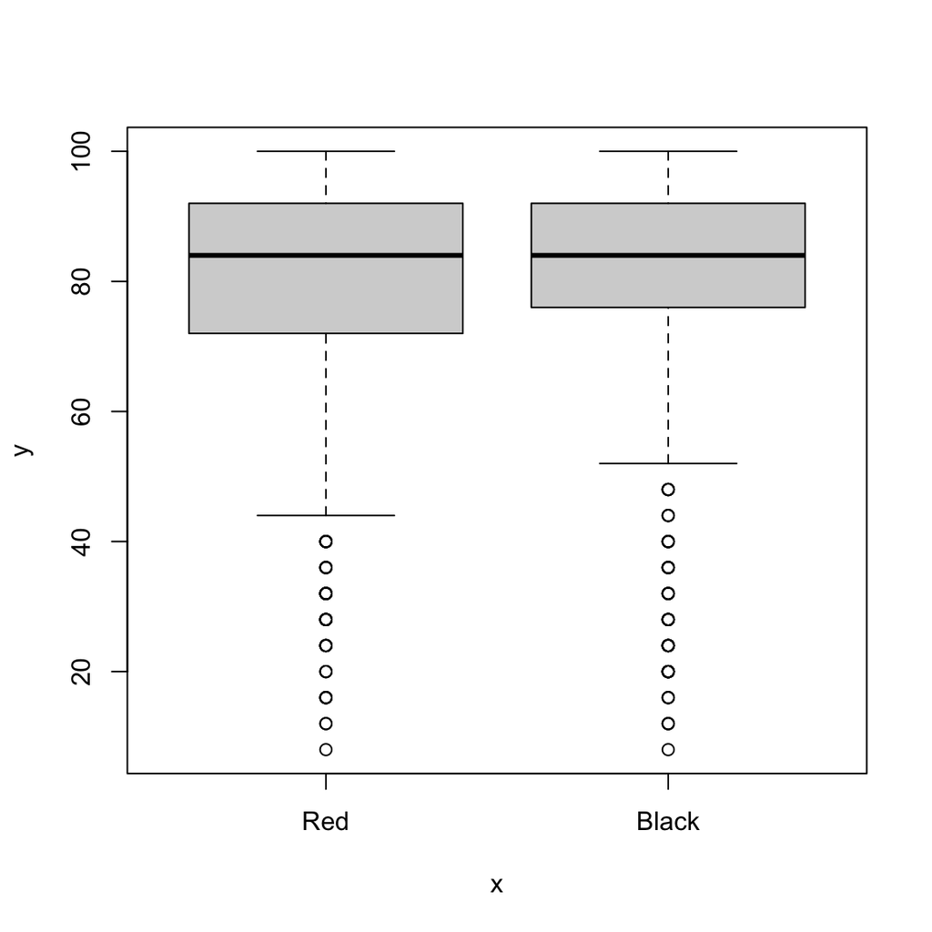

### QQ plot

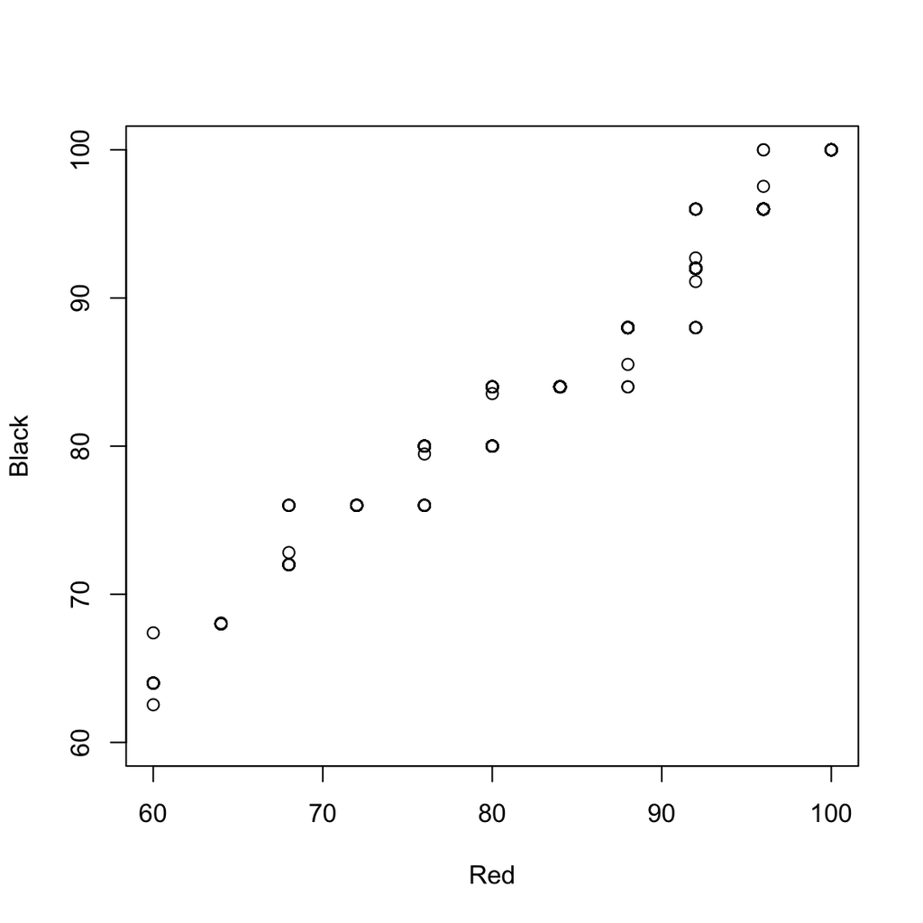

### ECDF plot

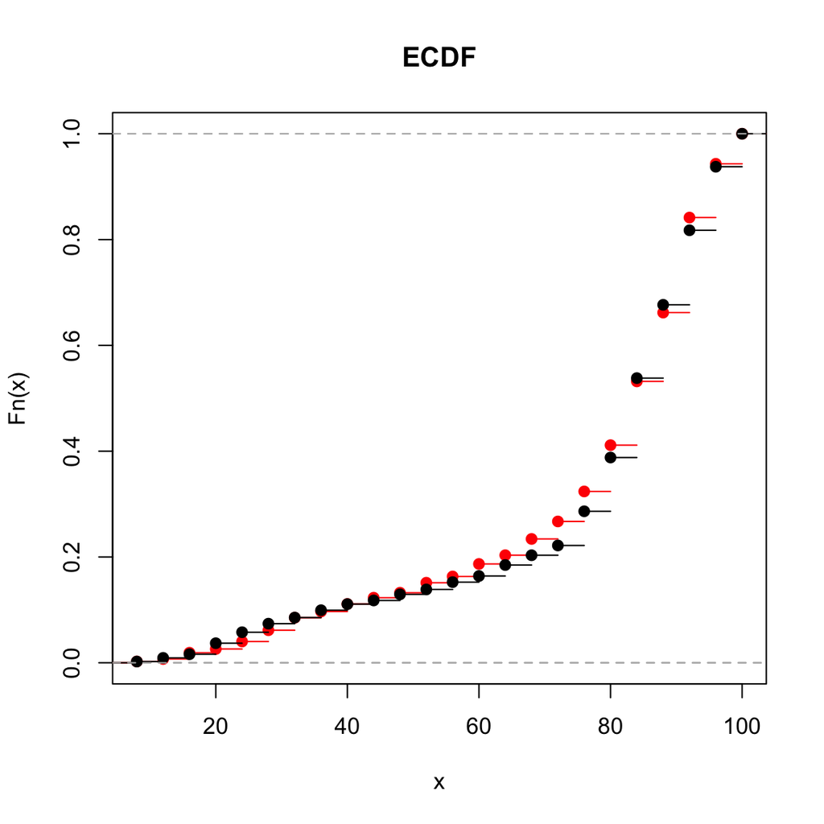

## t test

Welch Two Sample t-test: `score` by `.$group`

| Test statistic | df | P value | Alternative hypothesis | mean in group Red | mean in group Black |
| --- | --- | --- | --- | --- | --- |
| -0.48 | 853.8 | 0.6314 | two.sided | 77.5 | 78.21 |

## 문해력 등급 판정

- I수준(24점 이하), II수준(28 ~ 48점), III수준(52 ~ 72점), IV수준(76점 이상)

문해력 등급 분포

| I | II | III | IV | 계 |
| --- | --- | --- | --- | --- |
| 42 | 70 | 97 | 647 | 856 |

문해력 등급 분포(%)

| I | II | III | IV | 계 |
| --- | --- | --- | --- | --- |
| 4.91 | 8.18 | 11.33 | 75.58 | 100 |

그룹별 문해력 등급 분포

|  | I | II | III | IV | 계 |
| --- | --- | --- | --- | --- | --- |
| Red | 17 | 39 | 57 | 310 | 423 |
| Black | 25 | 31 | 40 | 337 | 433 |
| 계 | 42 | 70 | 97 | 647 | 856 |

Pearson’s Chi-squared test: `.`

[output not shown]

## 문항 유형별 점수 분석

## 유형별 정답률

|  | 유형 | 정답률(%) |
| --- | --- | --- |
| 문1 | 사실적 | 95.6 |
| 문2 | 사실적 | 86.2 |
| 문3 | 비판적 | 76.1 |
| 문4 | 사실적 | 93.6 |
| 문5 | 추론적 | 88.1 |
| 문6 | 추론적 | 64.7 |
| 문7 | 추론적 | 90.2 |
| 문8 | 사실적 | 73.0 |
| 문9 | 추론적 | 30.0 |
| 문10 | 추론적 | 83.9 |
| 문11 | 사실적 | 86.2 |
| 문12 | 사실적 | 60.7 |
| 문13 | 사실적 | 83.2 |
| 문14 | 추론적 | 84.0 |
| 문15 | 사실적 | 68.9 |
| 문16 | 사실적 | 79.3 |
| 문17 | 추론적 | 61.7 |
| 문18 | 비판적 | 84.9 |
| 문19 | 사실적 | 88.1 |
| 문20 | 사실적 | 79.8 |
| 문21 | 사실적 | 77.8 |
| 문22 | 비판적 | 68.3 |
| 문23 | 추론적 | 87.7 |
| 문24 | 사실적 | 77.8 |
| 문25 | 추론적 | 76.6 |

## 어려운 문제?

### 정답률 80% 이하

|  | 문3 | 문6 | 문8 | 문9 | 문12 | 문15 | 문16 | 문17 | 문20 | 문21 | 문22 | 문24 | 문25 |
| --- | --- | --- | --- | --- | --- | --- | --- | --- | --- | --- | --- | --- | --- |
| 정답률 | 76.1 | 64.7 | 73 | 30 | 60.7 | 68.9 | 79.3 | 61.7 | 79.8 | 77.8 | 68.3 | 77.8 | 76.6 |

### 정답률 70% 이하

|  | 문6 | 문9 | 문12 | 문15 | 문17 | 문22 |
| --- | --- | --- | --- | --- | --- | --- |
| 정답률 | 64.7 | 30 | 60.7 | 68.9 | 61.7 | 68.3 |

### 정답률 60% 이하

|  | 문9 |
| --- | --- |
| 정답률 | 30 |

### 정답률 50% 이하

|  | 문9 |
| --- | --- |
| 정답률 | 30 |

## 정답률이 낮은 문제들

### 문6.

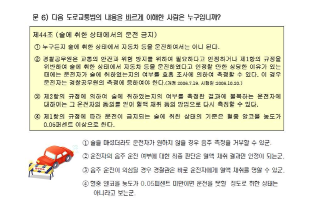

### 문9.

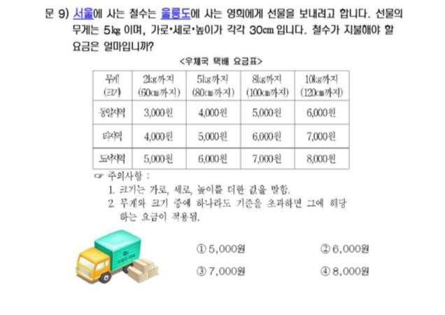

### 문12.

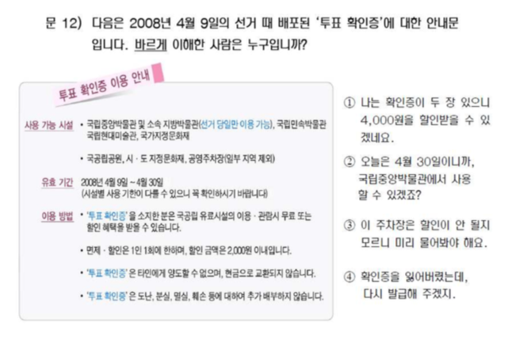

### 문15.

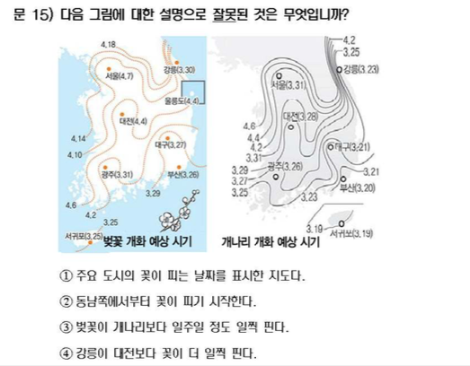

### 문17.

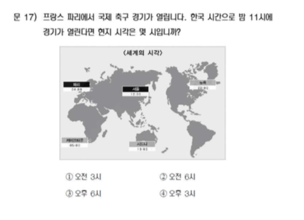

### 문22.

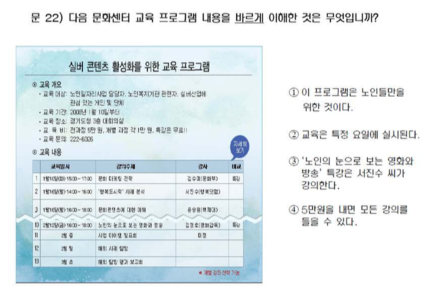